# Collecting and Exploring Data

Author

Jamal Rogers

## Learning Objectives

By the end of this lesson, students should be able to:

1. Understand the **types and sources of data** in data science.
2. Collect and organize data using **Polars** in Python.
3. Explore data using **summary statistics**.
4. Visualize data effectively using **Plotnine**.

## 1. Types of Data

In data science, data can be categorized into:

- **Numerical Data**

```
-    *Continuous*: values with infinite possibilities (e.g., height, temperature).

-    *Discrete*: countable values (e.g., number of students).
```

- **Categorical Data**

```
-    *Nominal*: categories without order (e.g., gender, color).

-    *Ordinal*: categories with order (e.g., grade levels).
```

- **Structured vs. Unstructured Data**

```
-    *Structured*: tabular (CSV, SQL, Excel).

-    *Unstructured*: text, images, audio, video.
```

## 2. Sources of Data

Common sources of data in applied data science:

- **Primary Data**: Surveys, experiments, observations.
- **Secondary Data**: Databases, open datasets (Kaggle, UCI ML Repository).
- **Automated Logs**: Website logs, LMS logs, IoT devices.
- **APIs & Web Scraping**: Collecting data programmatically.

## 3. Exploring Data with Polars

We’ll use the built-in **diamonds** dataset from `plotnine.data` to demonstrate.

```python
# Install required libraries if needed
# pip install polars plotnine

import polars as pl
from plotnine.data import diamonds

# Convert diamonds dataset (pandas -> polars)
diamonds_pl = pl.from_pandas(diamonds)

# Display first few rows
print(diamonds_pl.head())

# Summary statistics
print(diamonds_pl.describe())
```

```
shape: (5, 10)
┌───────┬─────────┬───────┬─────────┬───┬───────┬──────┬──────┬──────┐
│ carat ┆ cut     ┆ color ┆ clarity ┆ … ┆ price ┆ x    ┆ y    ┆ z    │
│ ---   ┆ ---     ┆ ---   ┆ ---     ┆   ┆ ---   ┆ ---  ┆ ---  ┆ ---  │
│ f64   ┆ cat     ┆ cat   ┆ cat     ┆   ┆ i64   ┆ f64  ┆ f64  ┆ f64  │
╞═══════╪═════════╪═══════╪═════════╪═══╪═══════╪══════╪══════╪══════╡
│ 0.23  ┆ Ideal   ┆ E     ┆ SI2     ┆ … ┆ 326   ┆ 3.95 ┆ 3.98 ┆ 2.43 │
│ 0.21  ┆ Premium ┆ E     ┆ SI1     ┆ … ┆ 326   ┆ 3.89 ┆ 3.84 ┆ 2.31 │
│ 0.23  ┆ Good    ┆ E     ┆ VS1     ┆ … ┆ 327   ┆ 4.05 ┆ 4.07 ┆ 2.31 │
│ 0.29  ┆ Premium ┆ I     ┆ VS2     ┆ … ┆ 334   ┆ 4.2  ┆ 4.23 ┆ 2.63 │
│ 0.31  ┆ Good    ┆ J     ┆ SI2     ┆ … ┆ 335   ┆ 4.34 ┆ 4.35 ┆ 2.75 │
└───────┴─────────┴───────┴─────────┴───┴───────┴──────┴──────┴──────┘
shape: (9, 11)
┌────────────┬──────────┬───────┬───────┬───┬─────────────┬──────────┬──────────┬──────────┐
│ statistic  ┆ carat    ┆ cut   ┆ color ┆ … ┆ price       ┆ x        ┆ y        ┆ z        │
│ ---        ┆ ---      ┆ ---   ┆ ---   ┆   ┆ ---         ┆ ---      ┆ ---      ┆ ---      │
│ str        ┆ f64      ┆ str   ┆ str   ┆   ┆ f64         ┆ f64      ┆ f64      ┆ f64      │
╞════════════╪══════════╪═══════╪═══════╪═══╪═════════════╪══════════╪══════════╪══════════╡
│ count      ┆ 53940.0  ┆ 53940 ┆ 53940 ┆ … ┆ 53940.0     ┆ 53940.0  ┆ 53940.0  ┆ 53940.0  │
│ null_count ┆ 0.0      ┆ 0     ┆ 0     ┆ … ┆ 0.0         ┆ 0.0      ┆ 0.0      ┆ 0.0      │
│ mean       ┆ 0.79794  ┆ null  ┆ null  ┆ … ┆ 3932.799722 ┆ 5.731157 ┆ 5.734526 ┆ 3.538734 │
│ std        ┆ 0.474011 ┆ null  ┆ null  ┆ … ┆ 3989.439738 ┆ 1.121761 ┆ 1.142135 ┆ 0.705699 │
│ min        ┆ 0.2      ┆ null  ┆ null  ┆ … ┆ 326.0       ┆ 0.0      ┆ 0.0      ┆ 0.0      │
│ 25%        ┆ 0.4      ┆ null  ┆ null  ┆ … ┆ 950.0       ┆ 4.71     ┆ 4.72     ┆ 2.91     │
│ 50%        ┆ 0.7      ┆ null  ┆ null  ┆ … ┆ 2401.0      ┆ 5.7      ┆ 5.71     ┆ 3.53     │
│ 75%        ┆ 1.04     ┆ null  ┆ null  ┆ … ┆ 5324.0      ┆ 6.54     ┆ 6.54     ┆ 4.04     │
│ max        ┆ 5.01     ┆ null  ┆ null  ┆ … ┆ 18823.0     ┆ 10.74    ┆ 58.9     ┆ 31.8     │
└────────────┴──────────┴───────┴───────┴───┴─────────────┴──────────┴──────────┴──────────┘
```

**Explanation**:

- `pl.from_pandas()` converts a pandas DataFrame to Polars for faster operations.
- `.describe()` generates summary statistics (mean, min, max, std, etc.).

## 4. Exploring Data with Graphs (Plotnine)

Plotnine is a grammar-of-graphics library (similar to ggplot2 in R).

### Example 1: Histogram of Diamond Prices

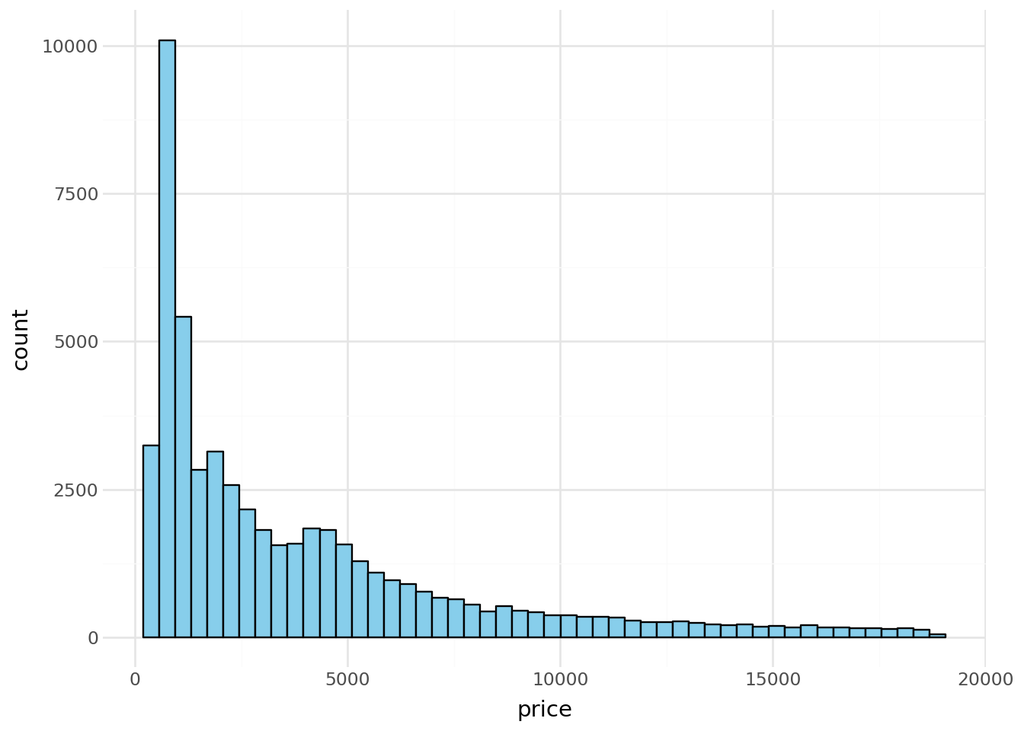

```python
from plotnine import ggplot, aes, geom_histogram, theme_minimal

ggplot(diamonds, aes(x="price")) + \
    geom_histogram(bins=50, fill="skyblue", color="black") + \
    theme_minimal()
```

### Example 2: Scatter Plot of Carat vs Price

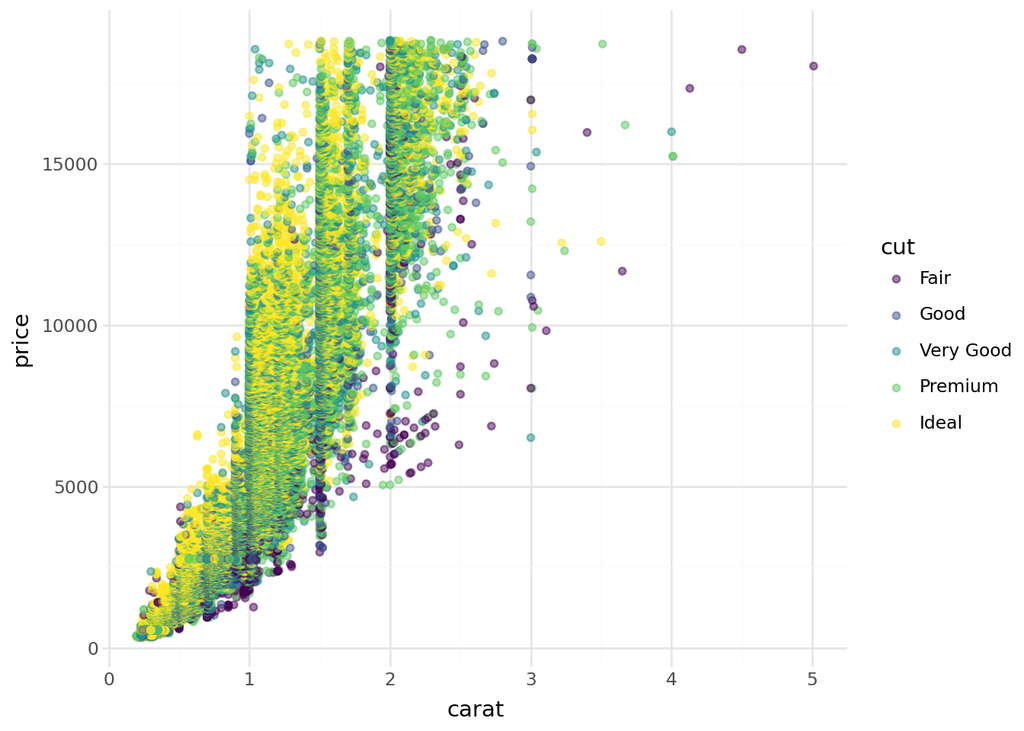

```python
from plotnine import geom_point

ggplot(diamonds, aes(x="carat", y="price", color="cut")) + \
    geom_point(alpha=0.5) + \
    theme_minimal()
```

### Example 3: Boxplot of Price by Cut

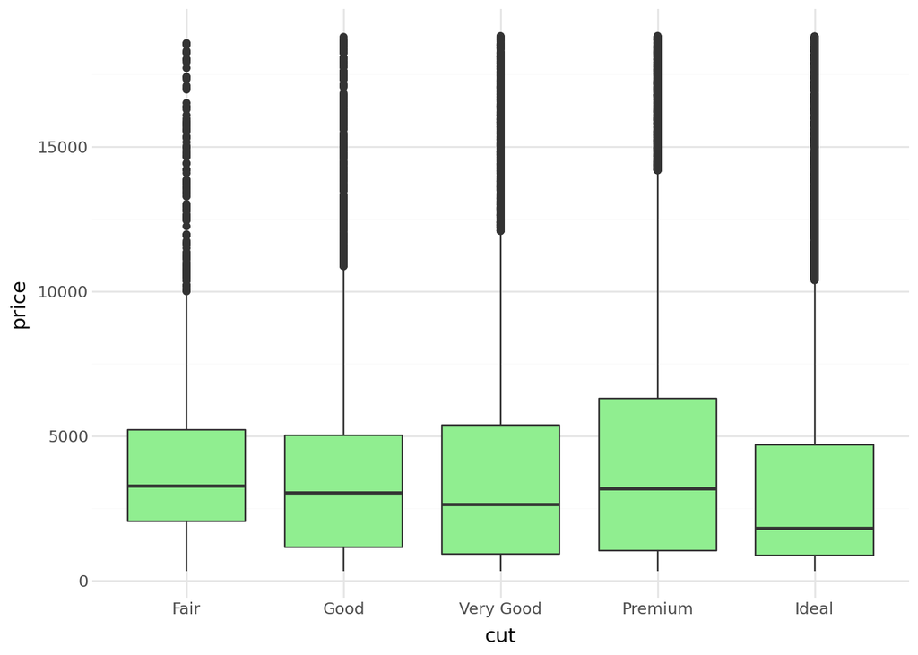

```python
from plotnine import geom_boxplot

ggplot(diamonds, aes(x="cut", y="price")) + \
    geom_boxplot(fill="lightgreen") + \
    theme_minimal()
```

## 5. Interpretation of Results

- The **histogram** shows the distribution of diamond prices (most diamonds are under $5,000).
- The **scatter plot** reveals a positive relationship between carat and price (bigger diamonds cost more).
- The **boxplot** shows variation in price across diamond cuts.

## Wrap-Up

In this lesson, we covered **types and sources of data**, how to **explore data with Polars**, and how to **visualize patterns with Plotnine**. These steps form the foundation of applied data science before moving into **data preprocessing** and **modeling**.

## Activity for Students

1. Load another dataset (e.g., Titanic from `plotnine.data`).
2. Use **Polars** to compute summary statistics of numerical features.
3. Create at least **two visualizations** with Plotnine:

```
-    One distribution plot (histogram or density).

-    One relationship plot (scatter, boxplot, or bar).
```

4. Interpret findings in 2–3 sentences.

*“Every line of code you write, every formula you solve, and every page you read is a step toward building the future only you can create.”*

- The Data Samurai

[figure not shown]